# Analysis Speech

Tom Offrede

2022-09-15

## Conditions:

**GA: Gaze Aversion; the robot produced gaze aversion. Experimental condition.** **NG: No Gaze aversion; the robot stared constantly at the human. Control condition.**

# Between-Turn Gap Duration

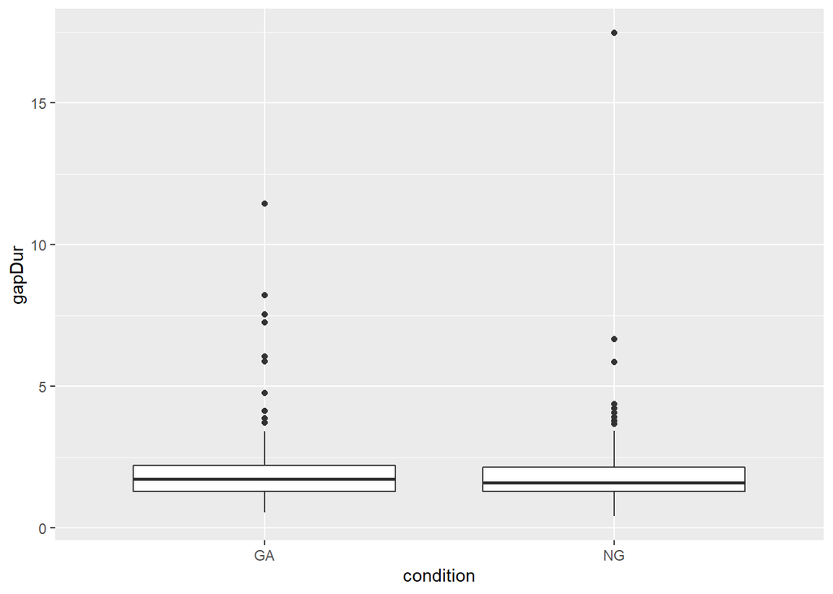

```r
ggplot(dac, aes(condition, gapDur))+
  geom_boxplot()
```

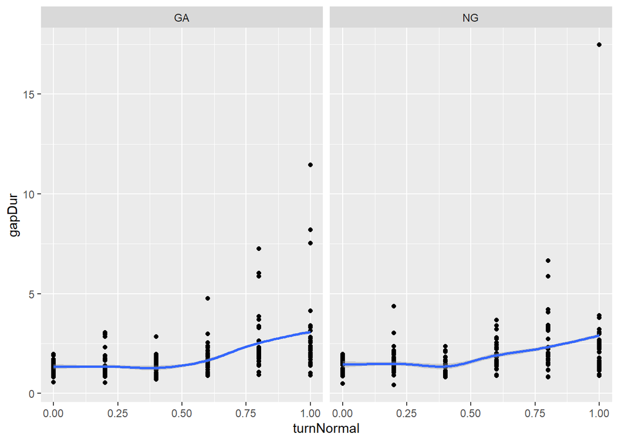

```r
ggplot(dac, aes(turnNormal, gapDur))+
  geom_point()+
  facet_wrap(~condition)+
  geom_smooth(method="loess")
```

```r
dac$condition <- relevel(dac$condition, ref="NG")
summary(g1 <- lmer(gapDur ~ condition * turnNormal + (1 + condition | speaker), dac))
```

```
## Linear mixed model fit by REML ['lmerMod']
## Formula: gapDur ~ condition * turnNormal + (1 + condition | speaker)
##    Data: dac
##
## REML criterion at convergence: 30387.9
##
## Scaled residuals:
##     Min      1Q  Median      3Q     Max
## -5.1636 -0.3654 -0.0409  0.2999  7.1624
##
## Random effects:
##  Groups   Name        Variance Std.Dev. Corr
##  speaker  (Intercept) 1.3703   1.1706
##           conditionGA 0.6926   0.8322   -0.66
##  Residual             1.5969   1.2637
## Number of obs: 9110, groups:  speaker, 33
##
## Fixed effects:
##                        Estimate Std. Error t value
## (Intercept)             1.26370    0.20759   6.088
## conditionGA            -0.34038    0.15564  -2.187
## turnNormal              1.39613    0.05682  24.572
## conditionGA:turnNormal  0.52927    0.08350   6.338
##
## Correlation of Fixed Effects:
##             (Intr) cndtGA trnNrm
## conditionGA -0.654
## turnNormal  -0.155  0.207
## cndtnGA:trN  0.106 -0.302 -0.680
```

```r
summary(g2 <- lmer(gapDur ~ condition * intimc + (1 + condition | speaker), dac))
```

```
## Linear mixed model fit by REML ['lmerMod']
## Formula: gapDur ~ condition * intimc + (1 + condition | speaker)
##    Data: dac
##
## REML criterion at convergence: 30428.7
##
## Scaled residuals:
##     Min      1Q  Median      3Q     Max
## -5.2197 -0.3211 -0.0380  0.2645  7.2856
##
## Random effects:
##  Groups   Name        Variance Std.Dev. Corr
##  speaker  (Intercept) 1.4438   1.2016
##           conditionGA 0.7271   0.8527   -0.68
##  Residual             1.6025   1.2659
## Number of obs: 9110, groups:  speaker, 33
##
## Fixed effects:
##                    Estimate Std. Error t value
## (Intercept)         2.06523    0.21044   9.814
## conditionGA        -0.07273    0.15185  -0.479
## intimc              0.24221    0.01052  23.024
## conditionGA:intimc  0.09974    0.01501   6.646
##
## Correlation of Fixed Effects:
##             (Intr) cndtGA intimc
## conditionGA -0.675
## intimc       0.002 -0.003
## cndtnGA:ntm -0.001  0.001 -0.702
```

```r
anova(g1, g2)
```

```
## refitting model(s) with ML (instead of REML)
```

```
## Data: dac
## Models:
## g1: gapDur ~ condition * turnNormal + (1 + condition | speaker)
## g2: gapDur ~ condition * intimc + (1 + condition | speaker)
##    npar   AIC   BIC logLik deviance Chisq Df Pr(>Chisq)
## g1    8 30392 30449 -15188    30376
## g2    8 30426 30483 -15205    30410     0  0
```

# Turn Duration

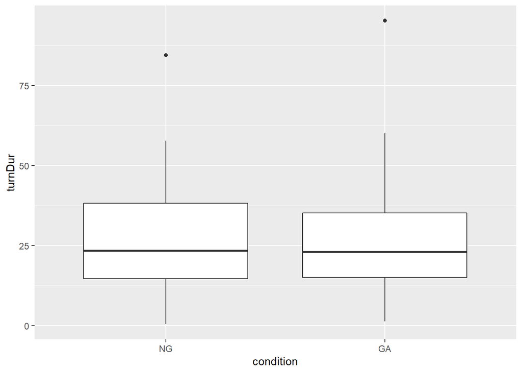

```r
ggplot(dac %>% filter(!grepl("Robot", speaker)), aes(condition, turnDur))+
  geom_boxplot()
```

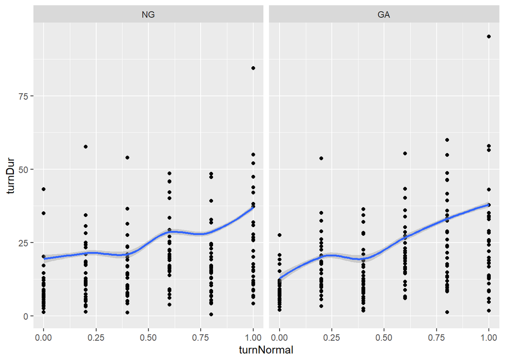

```r
ggplot(dac %>% filter(!grepl("Robot", speaker)), aes(turnNormal, turnDur))+
  geom_point()+
  facet_wrap(~condition)+
  geom_smooth(method="loess")
```

- There is a `turn` effect: the further into the conversation, the longer the turns
- There is a `turn : condition` interaction: in the GA condition (robot looks away; i.e. objectively more humanlike) the turns get longer throughout the conversation

The order of the `turn` has a .95 correlation with `intimacy` ratings, since the questions always followed the same order. So we can’t say if turn duration got higher with the progression of the conversation or because the questions got more intimate, or simply because the questions got more elaborate (so people had more things to talk about).

So if we make a model with `turn` or `intimacy`, both give the same results – the one with `turn` showing slightly larger effect sizes. The model with `turn` also has considerably lower AIC.

```r
cor.test(dac$turnNormal, dac$intimMean)
```

```
##
##  Pearson's product-moment correlation
##
## data:  dac$turnNormal and dac$intimMean
## t = 504.49, df = 25552, p-value < 2.2e-16
## alternative hypothesis: true correlation is not equal to 0
## 95 percent confidence interval:
##  0.9521585 0.9543961
## sample estimates:
##       cor
## 0.9532904
```

```r
dac$condition <- relevel(dac$condition, ref="NG")
summary(t1 <- lmer(turnDur ~ condition * turnNormal + (1 + condition | speaker), dac %>% filter(!grepl("Robot", speaker))))
```

```
## Linear mixed model fit by REML ['lmerMod']
## Formula: turnDur ~ condition * turnNormal + (1 + condition | speaker)
##    Data: dac %>% filter(!grepl("Robot", speaker))
##
## REML criterion at convergence: 65918.5
##
## Scaled residuals:
##     Min      1Q  Median      3Q     Max
## -3.7424 -0.6216  0.0339  0.6633  3.0442
##
## Random effects:
##  Groups   Name        Variance Std.Dev. Corr
##  speaker  (Intercept) 123.96   11.134
##           conditionGA  54.37    7.374   -0.36
##  Residual              78.63    8.867
## Number of obs: 9110, groups:  speaker, 33
##
## Fixed effects:
##                        Estimate Std. Error t value
## (Intercept)            11.18330    1.95796   5.712
## conditionGA             0.05715    1.34442   0.043
## turnNormal             16.82709    0.39874  42.201
## conditionGA:turnNormal  4.35449    0.58616   7.429
##
## Correlation of Fixed Effects:
##             (Intr) cndtGA trnNrm
## conditionGA -0.374
## turnNormal  -0.116  0.168
## cndtnGA:trN  0.079 -0.246 -0.680
```

```r
summary(t2 <- lmer(turnDur ~ condition * intimMean + (1 + condition | speaker), dac %>% filter(!grepl("Robot", speaker))))
```

```
## Linear mixed model fit by REML ['lmerMod']
## Formula: turnDur ~ condition * intimMean + (1 + condition | speaker)
##    Data: dac %>% filter(!grepl("Robot", speaker))
##
## REML criterion at convergence: 66692.5
##
## Scaled residuals:
##     Min      1Q  Median      3Q     Max
## -3.0884 -0.6439  0.0209  0.6005  3.2747
##
## Random effects:
##  Groups   Name        Variance Std.Dev. Corr
##  speaker  (Intercept) 125.83   11.217
##           conditionGA  55.66    7.460   -0.39
##  Residual              85.58    9.251
## Number of obs: 9110, groups:  speaker, 33
##
## Fixed effects:
##                       Estimate Std. Error t value
## (Intercept)            9.50440    1.98523   4.788
## conditionGA           -0.50564    1.39573  -0.362
## intimMean              2.73461    0.07688  35.568
## conditionGA:intimMean  0.64366    0.10967   5.869
##
## Correlation of Fixed Effects:
##             (Intr) cndtGA intmMn
## conditionGA -0.399
## intimMean   -0.159  0.226
## cndtnGA:ntM  0.112 -0.325 -0.701
```

```r
anova(t1, t2)
```

```
## refitting model(s) with ML (instead of REML)
```

```
## Data: dac %>% filter(!grepl("Robot", speaker))
## Models:
## t1: turnDur ~ condition * turnNormal + (1 + condition | speaker)
## t2: turnDur ~ condition * intimMean + (1 + condition | speaker)
##    npar   AIC   BIC logLik deviance Chisq Df Pr(>Chisq)
## t1    8 65940 65997 -32962    65924
## t2    8 66707 66764 -33346    66691     0  0
```

# f0 during conversation

## Look closer at f0 throughout time

(Check plots saved)

```r
# folderRobF0 <- "C:/Users/offredet/Documents/1HU/ExperimentEyes/Data/RobotsF0/"
# dat <- dac %>% filter(grepl("Robot", speaker))
#
# for(r in unique(dat$speaker)){
#   ggplot(dat %>% filter(speaker==r), aes(as.numeric(timeIndexOverall), f0mean))+
#     geom_point()+
#     facet_wrap(~condition)+
#     geom_smooth(method="loess")
#   ggsave(paste0(folderRobF0, r, ".png"))
# }
#
# folderPartF0 <- "C:/Users/offredet/Documents/1HU/ExperimentEyes/Data/ParticipantsF0/"
# dat <- dac %>% filter(!grepl("Robot", speaker))
#
# for(r in unique(dat$speaker)){
#   ggplot(dat %>% filter(speaker==r), aes(as.numeric(timeIndexOverall), f0mean))+
#     geom_point()+
#     facet_wrap(~condition)+
#     geom_smooth(method="loess")
#   ggsave(paste0(folderPartF0, r, ".png"))
# }
```

## Using the f0 from the IPUs of the robot’s previous turn as predictors for the f0 of the IPUs of the human’s current turn

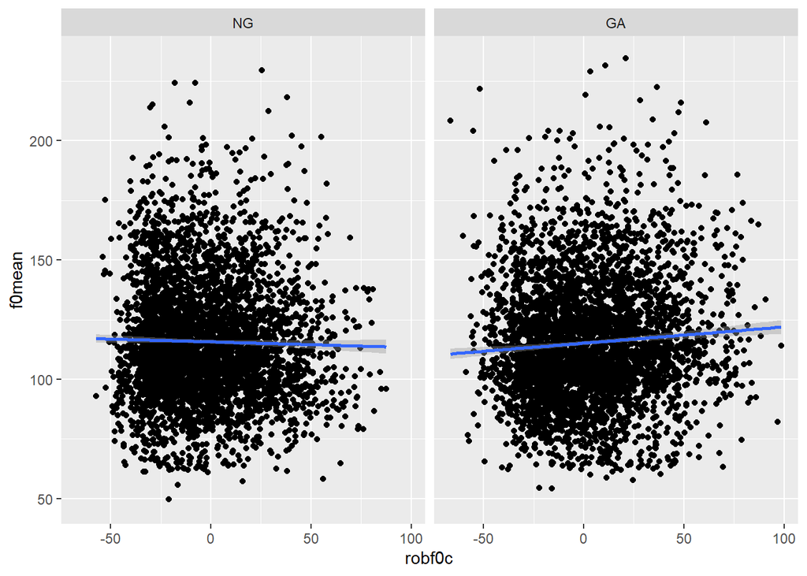

```r
ggplot(dac, aes(robf0c, f0mean))+
  geom_point()+
  facet_wrap(~condition)+
  geom_smooth(method="lm")
```

There is an effect of `robot's f0` in interaction with `condition`.

- `condition : robot's f0`: the robot’s f0 predicts the human’s f0 only in the staring condition.

See:

```r
dac$condition <- relevel(dac$condition, ref="NG")

summary(f1 <- lmer(f0mean ~ robf0c : condition + (1 + condition | speaker), dac %>% filter(!grepl("Robot", speaker))))
```

```
## Linear mixed model fit by REML ['lmerMod']
## Formula: f0mean ~ robf0c:condition + (1 + condition | speaker)
##    Data: dac %>% filter(!grepl("Robot", speaker))
##
## REML criterion at convergence: 70238.4
##
## Scaled residuals:
##     Min      1Q  Median      3Q     Max
## -5.0870 -0.5332 -0.1400  0.4191  5.3292
##
## Random effects:
##  Groups   Name        Variance Std.Dev. Corr
##  speaker  (Intercept) 277.3    16.653
##           conditionGA  18.6     4.313   0.05
##  Residual             368.8    19.203
## Number of obs: 8004, groups:  speaker, 33
##
## Fixed effects:
##                     Estimate Std. Error t value
## (Intercept)        1.152e+02  2.920e+00  39.446
## robf0c:conditionNG 3.782e-02  1.291e-02   2.931
## robf0c:conditionGA 2.951e-03  1.177e-02   0.251
##
## Correlation of Fixed Effects:
##             (Intr) rb0:NG
## rbf0c:cndNG  0.010
## rbf0c:cndGA  0.000 -0.020
```

### Intimacy

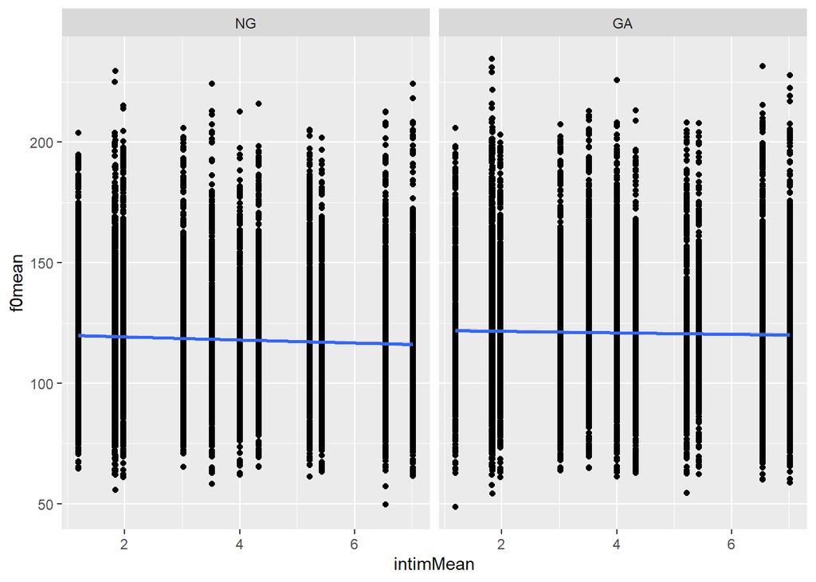

```r
ggplot(dac, aes(intimMean, f0mean))+
  geom_point()+
  facet_wrap(~condition)+
  geom_smooth(method="lm")
```

- `intimacy`: f0 gets lower with higher intimacy.

```r
summary(f1 <- lmer(f0mean ~ intimc + (1  | speaker), dac %>% filter(!grepl("Robot", speaker))))
```

```
## Linear mixed model fit by REML ['lmerMod']
## Formula: f0mean ~ intimc + (1 | speaker)
##    Data: dac %>% filter(!grepl("Robot", speaker))
##
## REML criterion at convergence: 79588.2
##
## Scaled residuals:
##     Min      1Q  Median      3Q     Max
## -5.1141 -0.5288 -0.1392  0.4025  5.4724
##
## Random effects:
##  Groups   Name        Variance Std.Dev.
##  speaker  (Intercept) 289.5    17.02
##  Residual             357.7    18.91
## Number of obs: 9110, groups:  speaker, 33
##
## Fixed effects:
##             Estimate Std. Error t value
## (Intercept) 114.8171     2.9715  38.639
## intimc       -0.5622     0.1088  -5.167
##
## Correlation of Fixed Effects:
##        (Intr)
## intimc 0.000
```

### BFI

#### Intellect/Openness

AIC of model with BFI dimension is higher.

```r
summary(intel1 <- lmer(f0mean ~ robf0c : IOc : condition + (1 + condition | speaker), dac %>% filter(!grepl("Robot", speaker))))
```

```
## Linear mixed model fit by REML ['lmerMod']
## Formula: f0mean ~ robf0c:IOc:condition + (1 + condition | speaker)
##    Data: dac %>% filter(!grepl("Robot", speaker))
##
## REML criterion at convergence: 70242.8
##
## Scaled residuals:
##     Min      1Q  Median      3Q     Max
## -5.0858 -0.5343 -0.1412  0.4210  5.3253
##
## Random effects:
##  Groups   Name        Variance Std.Dev. Corr
##  speaker  (Intercept) 274.61   16.571
##           conditionGA  20.47    4.524   0.07
##  Residual             368.99   19.209
## Number of obs: 8004, groups:  speaker, 33
##
## Fixed effects:
##                         Estimate Std. Error t value
## (Intercept)            115.05737    2.90499  39.607
## robf0c:IOc:conditionNG  -0.02367    0.02384  -0.993
## robf0c:IOc:conditionGA  -0.01916    0.02038  -0.940
##
## Correlation of Fixed Effects:
##             (Intr) r0:IO:N
## rbf0c:IO:NG  0.003
## rbf0c:IO:GA  0.000 -0.023
```

```r
summary(no1 <- lmer(f0mean ~ robf0c : condition + (1 + condition | speaker), dac %>% filter(!grepl("Robot", speaker))))
```

```
## Linear mixed model fit by REML ['lmerMod']
## Formula: f0mean ~ robf0c:condition + (1 + condition | speaker)
##    Data: dac %>% filter(!grepl("Robot", speaker))
##
## REML criterion at convergence: 70238.4
##
## Scaled residuals:
##     Min      1Q  Median      3Q     Max
## -5.0870 -0.5332 -0.1400  0.4191  5.3292
##
## Random effects:
##  Groups   Name        Variance Std.Dev. Corr
##  speaker  (Intercept) 277.3    16.653
##           conditionGA  18.6     4.313   0.05
##  Residual             368.8    19.203
## Number of obs: 8004, groups:  speaker, 33
##
## Fixed effects:
##                     Estimate Std. Error t value
## (Intercept)        1.152e+02  2.920e+00  39.446
## robf0c:conditionNG 3.782e-02  1.291e-02   2.931
## robf0c:conditionGA 2.951e-03  1.177e-02   0.251
##
## Correlation of Fixed Effects:
##             (Intr) rb0:NG
## rbf0c:cndNG  0.010
## rbf0c:cndGA  0.000 -0.020
```

```r
anova(intel1, no1)
```

```
## refitting model(s) with ML (instead of REML)
```

```
## Data: dac %>% filter(!grepl("Robot", speaker))
## Models:
## intel1: f0mean ~ robf0c:IOc:condition + (1 + condition | speaker)
## no1: f0mean ~ robf0c:condition + (1 + condition | speaker)
##        npar   AIC   BIC logLik deviance Chisq Df Pr(>Chisq)
## intel1    7 70249 70298 -35118    70235
## no1       7 70242 70291 -35114    70228 6.729  0
```

#### Agreeableness

```r
d <- dac %>%
  filter(!grepl("Robot", speaker)) %>%
  select(f0mean, robf0c, Agreec, Agreeableness, condition, speaker) %>%
  na.omit()

summary(agree1 <- lmer(f0mean ~ robf0c : Agreec : condition + (1 | speaker), d))
```

```
## Linear mixed model fit by REML ['lmerMod']
## Formula: f0mean ~ robf0c:Agreec:condition + (1 | speaker)
##    Data: d
##
## REML criterion at convergence: 68522
##
## Scaled residuals:
##     Min      1Q  Median      3Q     Max
## -5.0501 -0.5364 -0.1422  0.4237  5.3979
##
## Random effects:
##  Groups   Name        Variance Std.Dev.
##  speaker  (Intercept) 292.3    17.10
##  Residual             374.9    19.36
## Number of obs: 7799, groups:  speaker, 32
##
## Fixed effects:
##                            Estimate Std. Error t value
## (Intercept)               1.148e+02  3.033e+00  37.848
## robf0c:Agreec:conditionNG 8.837e-03  3.215e-02   0.275
## robf0c:Agreec:conditionGA 3.119e-02  2.648e-02   1.178
##
## Correlation of Fixed Effects:
##             (Intr) r0:A:N
## rbf0c:Ag:NG  0.000
## rbf0c:Ag:GA  0.000 -0.094
```

```r
summary(no1 <- lmer(f0mean ~ robf0c : condition + (1 | speaker), d))
```

```
## Linear mixed model fit by REML ['lmerMod']
## Formula: f0mean ~ robf0c:condition + (1 | speaker)
##    Data: d
##
## REML criterion at convergence: 68514.5
##
## Scaled residuals:
##     Min      1Q  Median      3Q     Max
## -4.9824 -0.5351 -0.1415  0.4166  5.4059
##
## Random effects:
##  Groups   Name        Variance Std.Dev.
##  speaker  (Intercept) 292.8    17.11
##  Residual             374.3    19.35
## Number of obs: 7799, groups:  speaker, 32
##
## Fixed effects:
##                     Estimate Std. Error t value
## (Intercept)        1.148e+02  3.035e+00  37.832
## robf0c:conditionNG 4.342e-02  1.279e-02   3.394
## robf0c:conditionGA 8.873e-03  1.161e-02   0.764
##
## Correlation of Fixed Effects:
##             (Intr) rb0:NG
## rbf0c:cndNG  0.006
## rbf0c:cndGA -0.006 -0.079
```

```r
anova(agree1, no1)
```

```
## refitting model(s) with ML (instead of REML)
```

```
## Data: d
## Models:
## agree1: f0mean ~ robf0c:Agreec:condition + (1 | speaker)
## no1: f0mean ~ robf0c:condition + (1 | speaker)
##        npar   AIC   BIC logLik deviance  Chisq Df Pr(>Chisq)
## agree1    5 68526 68560 -34258    68516
## no1       5 68515 68549 -34252    68505 11.047  0
```

#### Conscientiousness

```r
d <- dac %>%
  filter(!grepl("Robot", speaker)) %>%
  select(f0mean, robf0c, Conscc, condition, speaker) %>%
  na.omit()

summary(con1 <- lmer(f0mean ~ robf0c : Conscc : condition + (1 + condition | speaker), d))
```

```
## Linear mixed model fit by REML ['lmerMod']
## Formula: f0mean ~ robf0c:Conscc:condition + (1 + condition | speaker)
##    Data: d
##
## REML criterion at convergence: 68467.8
##
## Scaled residuals:
##     Min      1Q  Median      3Q     Max
## -5.0584 -0.5361 -0.1428  0.4213  5.3264
##
## Random effects:
##  Groups   Name        Variance Std.Dev. Corr
##  speaker  (Intercept) 276.48   16.628
##           conditionGA  20.46    4.523   0.09
##  Residual             370.16   19.240
## Number of obs: 7799, groups:  speaker, 32
##
## Fixed effects:
##                             Estimate Std. Error t value
## (Intercept)               114.526424   2.959060  38.704
## robf0c:Conscc:conditionNG   0.006539   0.022568   0.290
## robf0c:Conscc:conditionGA  -0.029425   0.019569  -1.504
##
## Correlation of Fixed Effects:
##             (Intr) r0:C:N
## rbf0c:Cn:NG -0.017
## rbf0c:Cn:GA -0.001 -0.022
```

```r
summary(no1 <- lmer(f0mean ~ robf0c : condition + (1 + condition | speaker), d))
```

```
## Linear mixed model fit by REML ['lmerMod']
## Formula: f0mean ~ robf0c:condition + (1 + condition | speaker)
##    Data: d
##
## REML criterion at convergence: 68463.9
##
## Scaled residuals:
##     Min      1Q  Median      3Q     Max
## -5.0810 -0.5321 -0.1426  0.4191  5.3197
##
## Random effects:
##  Groups   Name        Variance Std.Dev. Corr
##  speaker  (Intercept) 278.5    16.688
##           conditionGA  19.0     4.359   0.08
##  Residual             369.9    19.234
## Number of obs: 7799, groups:  speaker, 32
##
## Fixed effects:
##                     Estimate Std. Error t value
## (Intercept)        1.147e+02  2.970e+00  38.605
## robf0c:conditionNG 3.768e-02  1.311e-02   2.874
## robf0c:conditionGA 3.407e-03  1.189e-02   0.287
##
## Correlation of Fixed Effects:
##             (Intr) rb0:NG
## rbf0c:cndNG  0.013
## rbf0c:cndGA  0.001 -0.020
```

```r
anova(con1, no1)
```

```
## refitting model(s) with ML (instead of REML)
```

```
## Data: d
## Models:
## con1: f0mean ~ robf0c:Conscc:condition + (1 + condition | speaker)
## no1: f0mean ~ robf0c:condition + (1 + condition | speaker)
##      npar   AIC   BIC logLik deviance  Chisq Df Pr(>Chisq)
## con1    7 68474 68523 -34230    68460
## no1     7 68468 68517 -34227    68454 6.0093  0
```

#### EmotionalStability

```r
d <- dac %>%
  filter(!grepl("Robot", speaker)) %>%
  select(f0mean, robf0c, ESc, condition, speaker, intimc) %>%
  na.omit()

summary(em1 <- lmer(f0mean ~ robf0c : ESc : condition + (1 + condition | speaker), d))
```

```
## Linear mixed model fit by REML ['lmerMod']
## Formula: f0mean ~ robf0c:ESc:condition + (1 + condition | speaker)
##    Data: d
##
## REML criterion at convergence: 68464.8
##
## Scaled residuals:
##     Min      1Q  Median      3Q     Max
## -5.0445 -0.5330 -0.1445  0.4238  5.3391
##
## Random effects:
##  Groups   Name        Variance Std.Dev. Corr
##  speaker  (Intercept) 278.05   16.675
##           conditionGA  20.28    4.503   0.08
##  Residual             369.96   19.234
## Number of obs: 7799, groups:  speaker, 32
##
## Fixed effects:
##                         Estimate Std. Error t value
## (Intercept)            114.62913    2.96778  38.625
## robf0c:ESc:conditionNG   0.03407    0.01686   2.020
## robf0c:ESc:conditionGA  -0.02258    0.01379  -1.637
##
## Correlation of Fixed Effects:
##             (Intr) r0:ES:N
## rbf0c:ES:NG  0.015
## rbf0c:ES:GA  0.001 -0.019
```

```r
summary(no1 <- lmer(f0mean ~ robf0c : condition + (1 + condition | speaker), d))
```

```
## Linear mixed model fit by REML ['lmerMod']
## Formula: f0mean ~ robf0c:condition + (1 + condition | speaker)
##    Data: d
##
## REML criterion at convergence: 68463.9
##
## Scaled residuals:
##     Min      1Q  Median      3Q     Max
## -5.0810 -0.5321 -0.1426  0.4191  5.3197
##
## Random effects:
##  Groups   Name        Variance Std.Dev. Corr
##  speaker  (Intercept) 278.5    16.688
##           conditionGA  19.0     4.359   0.08
##  Residual             369.9    19.234
## Number of obs: 7799, groups:  speaker, 32
##
## Fixed effects:
##                     Estimate Std. Error t value
## (Intercept)        1.147e+02  2.970e+00  38.605
## robf0c:conditionNG 3.768e-02  1.311e-02   2.874
## robf0c:conditionGA 3.407e-03  1.189e-02   0.287
##
## Correlation of Fixed Effects:
##             (Intr) rb0:NG
## rbf0c:cndNG  0.013
## rbf0c:cndGA  0.001 -0.020
```

```r
anova(em1, no1)
```

```
## refitting model(s) with ML (instead of REML)
```

```
## Data: d
## Models:
## em1: f0mean ~ robf0c:ESc:condition + (1 + condition | speaker)
## no1: f0mean ~ robf0c:condition + (1 + condition | speaker)
##     npar   AIC   BIC logLik deviance  Chisq Df Pr(>Chisq)
## em1    7 68470 68518 -34228    68456
## no1    7 68468 68517 -34227    68454 1.7066  0
```

#### Extraversion

AIC higher

```r
summary(ex1 <- lmer(f0mean ~ robf0c : Extrac : condition + (1 + condition | speaker), dac %>% filter(!grepl("Robot", speaker))))
```

```
## Linear mixed model fit by REML ['lmerMod']
## Formula: f0mean ~ robf0c:Extrac:condition + (1 + condition | speaker)
##    Data: dac %>% filter(!grepl("Robot", speaker))
##
## REML criterion at convergence: 70244.9
##
## Scaled residuals:
##     Min      1Q  Median      3Q     Max
## -5.0790 -0.5363 -0.1419  0.4257  5.3358
##
## Random effects:
##  Groups   Name        Variance Std.Dev. Corr
##  speaker  (Intercept) 276.88   16.640
##           conditionGA  20.27    4.502   0.05
##  Residual             368.99   19.209
## Number of obs: 8004, groups:  speaker, 33
##
## Fixed effects:
##                             Estimate Std. Error t value
## (Intercept)               115.055343   2.917219  39.440
## robf0c:Extrac:conditionNG  -0.019558   0.014443  -1.354
## robf0c:Extrac:conditionGA   0.003187   0.011913   0.268
##
## Correlation of Fixed Effects:
##             (Intr) r0:E:N
## rbf0c:Ex:NG  0.007
## rbf0c:Ex:GA  0.000 -0.019
```

```r
summary(no1 <- lmer(f0mean ~ robf0c : condition + (1 + condition | speaker), dac %>% filter(!grepl("Robot", speaker))))
```

```
## Linear mixed model fit by REML ['lmerMod']
## Formula: f0mean ~ robf0c:condition + (1 + condition | speaker)
##    Data: dac %>% filter(!grepl("Robot", speaker))
##
## REML criterion at convergence: 70238.4
##
## Scaled residuals:
##     Min      1Q  Median      3Q     Max
## -5.0870 -0.5332 -0.1400  0.4191  5.3292
##
## Random effects:
##  Groups   Name        Variance Std.Dev. Corr
##  speaker  (Intercept) 277.3    16.653
##           conditionGA  18.6     4.313   0.05
##  Residual             368.8    19.203
## Number of obs: 8004, groups:  speaker, 33
##
## Fixed effects:
##                     Estimate Std. Error t value
## (Intercept)        1.152e+02  2.920e+00  39.446
## robf0c:conditionNG 3.782e-02  1.291e-02   2.931
## robf0c:conditionGA 2.951e-03  1.177e-02   0.251
##
## Correlation of Fixed Effects:
##             (Intr) rb0:NG
## rbf0c:cndNG  0.010
## rbf0c:cndGA  0.000 -0.020
```

```r
anova(ex1, no1)
```

```
## refitting model(s) with ML (instead of REML)
```

```
## Data: dac %>% filter(!grepl("Robot", speaker))
## Models:
## ex1: f0mean ~ robf0c:Extrac:condition + (1 + condition | speaker)
## no1: f0mean ~ robf0c:condition + (1 + condition | speaker)
##     npar   AIC   BIC logLik deviance  Chisq Df Pr(>Chisq)
## ex1    7 70249 70298 -35118    70235
## no1    7 70242 70291 -35114    70228 6.7547  0
```

(Find a way to visualize the relationship of f0mean ~ robf0c * BFI * condition. e.g. heat map with facet_wrap?)

```r
# ggplot(dac, aes(IOc, robf0c))+
#   geom_point()+
#   facet_wrap(~condition)+
#   geom_smooth(method = "lm")+
#   ggtitle("IntellectOpenness")
#
# ggplot(dac, aes(Extrac, robf0c))+
#   geom_point()+
#   facet_wrap(~condition)+
#   geom_smooth(method = "lm")+
#   ggtitle("Extraversion")
#
# ggplot(dac, aes(ESc, robf0c))+
#   geom_point()+
#   facet_wrap(~condition)+
#   geom_smooth(method = "lm")+
#   ggtitle("Emotional Stability")
#
# ggplot(dac, aes(Agreec, robf0c))+
#   geom_point()+
#   facet_wrap(~condition)+
#   geom_smooth(method = "lm")+
#   ggtitle("Agreeableness")
#
# d <- as.matrix(dac %>% select(Conscc, f0mean, robf0c))
# wireframe(f0mean ~ Conscc * robf0c, dac %>% filter)
#
# ggplot(dac, aes(robf0c, f0mean))+
#   geom_contour()+
#   # facet_wrap(~condition)+
#   # geom_smooth(method = "lm")+
#   ggtitle("Conscientiousness")
```

### Questionnaire dimensions

Same procedure as for the BFI dimensions. **THESE MODELS CONFLATE BOTH CONDITIONS**

These 2 dimensions were obtained through a PCA of the questionnaire ratings. I am calling them *Conversational Quality* and *Robot’s Quality*. These are the items making up each dimension:

**Conversational quality**:

- My conversation with the robot flowed well.
- I was able to understand when the robot wanted me to speak.
- I was able to understand when the robot wanted to keep speaking.
- I enjoyed talking with the robot.
- I felt positively about the robot.
- I felt positively about the conversation.
- I felt comfortable while talking with the robot.

**Robot’s quality**:

- The robot responded to me at the appropriate time.
- The robot’s face was very human-like.
- The robot’s voice was very human-like.
- The robot’s behavior was very human-like.

**Conclusion** of questionnaire dimensions: There is a tendency for *conversational quality* and *robot’s quality* to predict convergence. See details for each dimension below.

#### Principal Component: Conversation Quality

AIC is slightly lower and t value higher. People that rated the conversation as better quality (see above) seemed to converge to the robot more.

```r
summary(cf1 <- lmer(f0mean ~ robf0c : PCConvQuality + (1 | speaker), dac %>% filter(!grepl("Robot", speaker))))
```

```
## Linear mixed model fit by REML ['lmerMod']
## Formula: f0mean ~ robf0c:PCConvQuality + (1 | speaker)
##    Data: dac %>% filter(!grepl("Robot", speaker))
##
## REML criterion at convergence: 70289.3
##
## Scaled residuals:
##     Min      1Q  Median      3Q     Max
## -5.0117 -0.5355 -0.1426  0.4212  5.4217
##
## Random effects:
##  Groups   Name        Variance Std.Dev.
##  speaker  (Intercept) 288.8    16.99
##  Residual             373.2    19.32
## Number of obs: 8004, groups:  speaker, 33
##
## Fixed effects:
##                       Estimate Std. Error t value
## (Intercept)          1.152e+02  2.968e+00  38.811
## robf0c:PCConvQuality 3.778e-03  1.161e-03   3.253
##
## Correlation of Fixed Effects:
##             (Intr)
## rbf0c:PCCnQ 0.000
```

```r
summary(no1 <- lmer(f0mean ~ robf0c + (1 | speaker), dac %>% filter(!grepl("Robot", speaker))))
```

```
## Linear mixed model fit by REML ['lmerMod']
## Formula: f0mean ~ robf0c + (1 | speaker)
##    Data: dac %>% filter(!grepl("Robot", speaker))
##
## REML criterion at convergence: 70286.8
##
## Scaled residuals:
##     Min      1Q  Median      3Q     Max
## -5.0113 -0.5360 -0.1428  0.4210  5.4206
##
## Random effects:
##  Groups   Name        Variance Std.Dev.
##  speaker  (Intercept) 288.7    16.99
##  Residual             373.2    19.32
## Number of obs: 8004, groups:  speaker, 33
##
## Fixed effects:
##              Estimate Std. Error t value
## (Intercept) 1.152e+02  2.968e+00  38.812
## robf0c      2.475e-02  8.151e-03   3.036
##
## Correlation of Fixed Effects:
##        (Intr)
## robf0c 0.000
```

```r
anova(cf1, no1)
```

```
## refitting model(s) with ML (instead of REML)
```

```
## Data: dac %>% filter(!grepl("Robot", speaker))
## Models:
## cf1: f0mean ~ robf0c:PCConvQuality + (1 | speaker)
## no1: f0mean ~ robf0c + (1 | speaker)
##     npar   AIC   BIC logLik deviance Chisq Df Pr(>Chisq)
## cf1    4 70290 70318 -35141    70282
## no1    4 70291 70319 -35142    70283     0  0
```

#### Principal Component: Robot’s Quality

AIC is slightly lower and t value higher. So there seems to be a tendency for people to converge more to the robot they rated as higher quality.

```r
summary(hl1 <- lmer(f0mean ~ robf0c : PCRobotQuality + (1  | speaker), dac %>% filter(!grepl("Robot", speaker))))
```

```
## Linear mixed model fit by REML ['lmerMod']
## Formula: f0mean ~ robf0c:PCRobotQuality + (1 | speaker)
##    Data: dac %>% filter(!grepl("Robot", speaker))
##
## REML criterion at convergence: 70288.9
##
## Scaled residuals:
##     Min      1Q  Median      3Q     Max
## -5.0133 -0.5344 -0.1425  0.4208  5.4223
##
## Random effects:
##  Groups   Name        Variance Std.Dev.
##  speaker  (Intercept) 288.6    16.99
##  Residual             373.2    19.32
## Number of obs: 8004, groups:  speaker, 33
##
## Fixed effects:
##                        Estimate Std. Error t value
## (Intercept)           1.152e+02  2.968e+00  38.825
## robf0c:PCRobotQuality 4.345e-03  1.323e-03   3.285
##
## Correlation of Fixed Effects:
##             (Intr)
## rbf0c:PCRbQ 0.001
```

```r
summary(no1 <- lmer(f0mean ~ robf0c + (1 | speaker), dac %>% filter(!grepl("Robot", speaker))))
```

```
## Linear mixed model fit by REML ['lmerMod']
## Formula: f0mean ~ robf0c + (1 | speaker)
##    Data: dac %>% filter(!grepl("Robot", speaker))
##
## REML criterion at convergence: 70286.8
##
## Scaled residuals:
##     Min      1Q  Median      3Q     Max
## -5.0113 -0.5360 -0.1428  0.4210  5.4206
##
## Random effects:
##  Groups   Name        Variance Std.Dev.
##  speaker  (Intercept) 288.7    16.99
##  Residual             373.2    19.32
## Number of obs: 8004, groups:  speaker, 33
##
## Fixed effects:
##              Estimate Std. Error t value
## (Intercept) 1.152e+02  2.968e+00  38.812
## robf0c      2.475e-02  8.151e-03   3.036
##
## Correlation of Fixed Effects:
##        (Intr)
## robf0c 0.000
```

```r
anova(hl1, no1)
```

```
## refitting model(s) with ML (instead of REML)
```

```
## Data: dac %>% filter(!grepl("Robot", speaker))
## Models:
## hl1: f0mean ~ robf0c:PCRobotQuality + (1 | speaker)
## no1: f0mean ~ robf0c + (1 | speaker)
##     npar   AIC   BIC logLik deviance Chisq Df Pr(>Chisq)
## hl1    4 70289 70317 -35141    70281
## no1    4 70291 70319 -35142    70283     0  0
```

### Checking with mock f0 data

Now check how robust this is with `robPreviousf0Mock`:

```r
dac$condition <- relevel(dac$condition, ref="GA")
summary(f2 <- lmer(f0mean ~ intimMean + robPrevf0Mock : condition + (1 + condition | speaker), dac %>% filter(!grepl("Robot", speaker))))
```

```
## Linear mixed model fit by REML ['lmerMod']
## Formula: f0mean ~ intimMean + robPrevf0Mock:condition + (1 + condition |
##     speaker)
##    Data: dac %>% filter(!grepl("Robot", speaker))
##
## REML criterion at convergence: 70164.1
##
## Scaled residuals:
##     Min      1Q  Median      3Q     Max
## -5.0719 -0.5239 -0.1369  0.4138  5.2990
##
## Random effects:
##  Groups   Name        Variance Std.Dev. Corr
##  speaker  (Intercept) 310.12   17.610
##           conditionNG  21.74    4.663   -0.37
##  Residual             366.26   19.138
## Number of obs: 8001, groups:  speaker, 33
##
## Fixed effects:
##                             Estimate Std. Error t value
## (Intercept)               111.982853   3.153594  35.510
## intimMean                  -0.447679   0.120601  -3.712
## robPrevf0Mock:conditionGA   0.042964   0.009485   4.530
## robPrevf0Mock:conditionNG   0.039036   0.008888   4.392
##
## Correlation of Fixed Effects:
##             (Intr) intmMn rP0M:G
## intimMean   -0.161
## rbPrvf0M:GA -0.234  0.015
## rbPrvf0M:NG -0.370  0.023  0.707
```

## Using the difference between the human’s mean f0 in the current turn and the robot’s mean f0 in the preceding turn

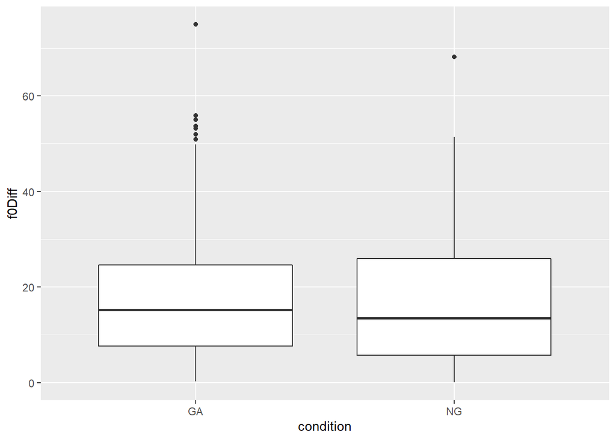

```r
ggplot(dat, aes(condition, f0Diff))+
  geom_boxplot()
```

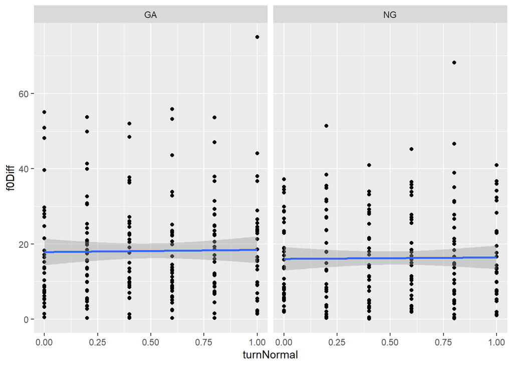

```r
ggplot(dat, aes(turnNormal, f0Diff))+
  geom_point()+
  facet_wrap(~condition)+
  geom_smooth(method="lm")
```

Using this method we don’t see any effect on f0.

```r
summary(ft1 <- lmer(f0Diff ~ condition * turnNormal + (1 + condition | speaker), dat))
```

```
## Linear mixed model fit by REML ['lmerMod']
## Formula: f0Diff ~ condition * turnNormal + (1 + condition | speaker)
##    Data: dat
##
## REML criterion at convergence: 2854.1
##
## Scaled residuals:
##     Min      1Q  Median      3Q     Max
## -3.0021 -0.5146  0.0018  0.5506  5.2953
##
## Random effects:
##  Groups   Name        Variance Std.Dev. Corr
##  speaker  (Intercept) 138.15   11.754
##           conditionNG 244.39   15.633   -0.74
##  Residual              56.91    7.544
## Number of obs: 392, groups:  speaker, 33
##
## Fixed effects:
##                        Estimate Std. Error t value
## (Intercept)             17.7197     2.2571   7.851
## conditionNG             -1.6705     3.0369  -0.550
## turnNormal               1.0839     1.5901   0.682
## conditionNG:turnNormal  -0.4954     2.2417  -0.221
##
## Correlation of Fixed Effects:
##             (Intr) cndtNG trnNrm
## conditionNG -0.736
## turnNormal  -0.348  0.259
## cndtnNG:trN  0.247 -0.366 -0.709
```

# f0 during baseline

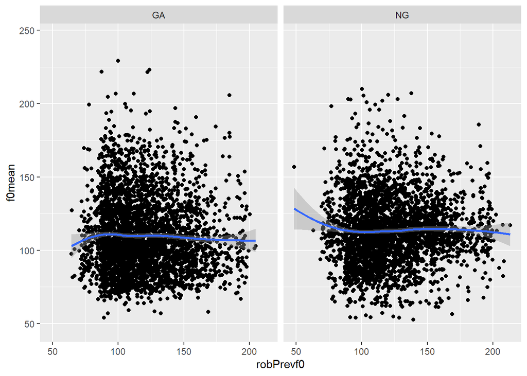

```r
ggplot(dab, aes(robPrevf0, f0mean))+
  geom_point()+
  facet_wrap(~condition)+
  geom_smooth(method="loess")
```

There is no lasting convergence effect.

```r
dab$condition <- relevel(dab$condition, ref="GA")
summary(fb2 <- lmer(f0mean ~ robPrevf0 : condition + (1 | speaker), dab))
```

```
## Linear mixed model fit by REML ['lmerMod']
## Formula: f0mean ~ robPrevf0:condition + (1 | speaker)
##    Data: dab
##
## REML criterion at convergence: 54381.5
##
## Scaled residuals:
##     Min      1Q  Median      3Q     Max
## -4.4755 -0.5194 -0.1430  0.4345  5.5266
##
## Random effects:
##  Groups   Name        Variance Std.Dev.
##  speaker  (Intercept) 355.8    18.86
##  Residual             288.8    17.00
## Number of obs: 6373, groups:  speaker, 33
##
## Fixed effects:
##                         Estimate Std. Error t value
## (Intercept)           113.896845   3.440253  33.107
## robPrevf0:conditionGA  -0.005984   0.011415  -0.524
## robPrevf0:conditionNG  -0.007047   0.011584  -0.608
##
## Correlation of Fixed Effects:
##             (Intr) rP0:GA
## rbPrvf0:cGA -0.223
## rbPrvf0:cNG -0.197  0.044
```

Similar result with robot’s *mock* f0.

```r
summary(fbM <- lmer(f0mean ~ robPrevf0Mock : condition + (1 | speaker), dab))
```

```
## Linear mixed model fit by REML ['lmerMod']
## Formula: f0mean ~ robPrevf0Mock:condition + (1 | speaker)
##    Data: dab
##
## REML criterion at convergence: 53733.4
##
## Scaled residuals:
##     Min      1Q  Median      3Q     Max
## -4.5330 -0.5038 -0.1342  0.4415  5.1890
##
## Random effects:
##  Groups   Name        Variance Std.Dev.
##  speaker  (Intercept) 347.3    18.63
##  Residual             352.8    18.78
## Number of obs: 6153, groups:  speaker, 33
##
## Fixed effects:
##                            Estimate Std. Error t value
## (Intercept)               116.49834    3.44399  33.827
## robPrevf0Mock:conditionGA  -0.01771    0.01302  -1.361
## robPrevf0Mock:conditionNG  -0.01044    0.01276  -0.818
##
## Correlation of Fixed Effects:
##             (Intr) rP0M:G
## rbPrvf0M:GA -0.225
## rbPrvf0M:NG -0.252  0.057
```

# Questionnaire ratings and condition

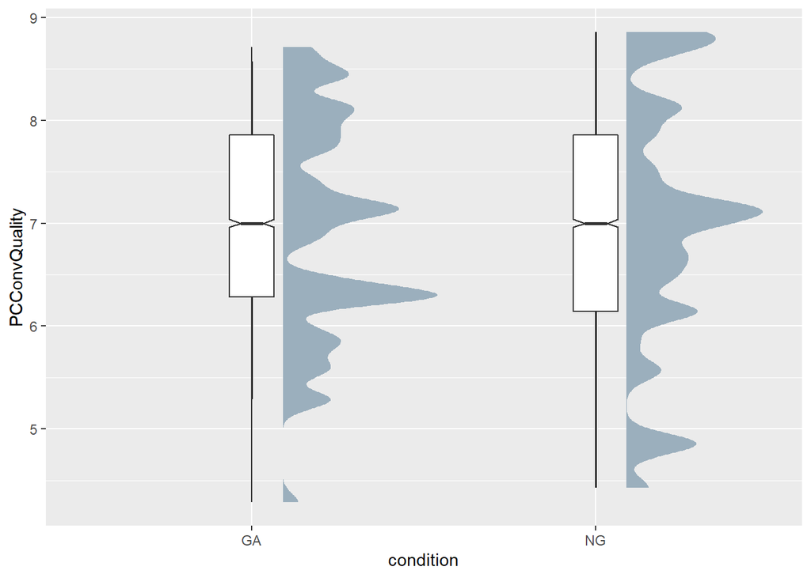

```r
ggplot(dac, aes(condition, PCConvQuality))+
  stat_halfeye(adjust = .5,  width = .5, justification = -.2, .width = c(.5, .95), fill="#9bafbd")+
  geom_boxplot(width=.13, notch = TRUE)
```

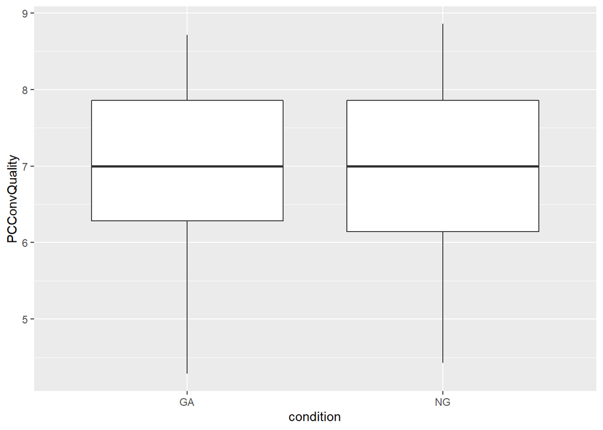

```r
ggplot(dac, aes(condition, PCConvQuality))+
  geom_boxplot()
```

From the graphs, you’d think there’s either no difference between conditions or that `GA` has slightly higher ratings. The regression is confusing about it:

- If you include a random slope of `condition` per `speaker`, the model doesn’t converge
- If you only include the random intercept for `speaker`, the condition `NG` is shown to have higher ratings.

I doubt the robustness of this result.

(Model’s residuals: homoskedastic (good) but far from normally distributed.)

```r
summary(cq1 <- lmer(PCConvQuality ~ condition + (1|speaker), dac))
```

```
## Linear mixed model fit by REML ['lmerMod']
## Formula: PCConvQuality ~ condition + (1 | speaker)
##    Data: dac
##
## REML criterion at convergence: 11429.4
##
## Scaled residuals:
##      Min       1Q   Median       3Q      Max
## -2.15337 -0.74564 -0.01903  0.70316  2.90385
##
## Random effects:
##  Groups   Name        Variance Std.Dev.
##  speaker  (Intercept) 1.2313   1.110
##  Residual             0.1998   0.447
## Number of obs: 9110, groups:  speaker, 33
##
## Fixed effects:
##             Estimate Std. Error t value
## (Intercept)  6.95973    0.19330  36.005
## conditionNG  0.02514    0.00957   2.627
##
## Correlation of Fixed Effects:
##             (Intr)
## conditionNG -0.025
```

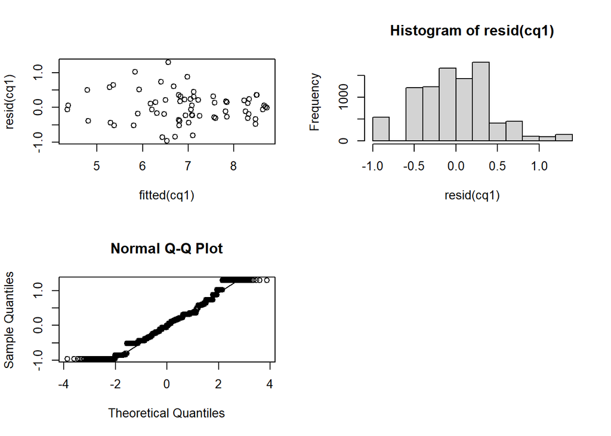

```r
par(mfrow=c(2,2))
plot(fitted(cq1), resid(cq1))
hist(resid(cq1))
qqnorm(resid(cq1));qqline(resid(cq1))
```

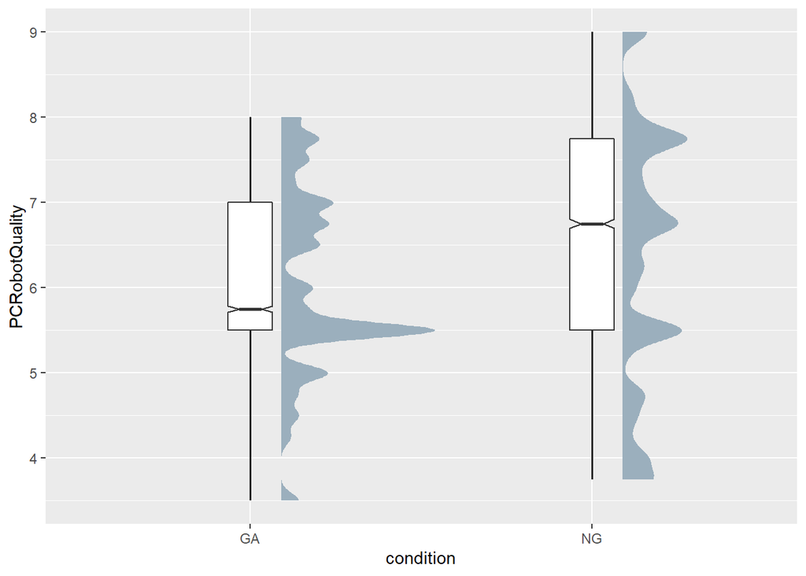

```r
ggplot(dac, aes(condition, PCRobotQuality))+
  stat_halfeye(adjust = .5,  width = .5, justification = -.2, .width = c(.5, .95), fill="#9bafbd")+
  geom_boxplot(width=.13, notch = TRUE)
```

For the “robot’s quality” ratings, the `NG` condition was rated higher – opposite from our hypothesis.

(Model’s residuals: also homoskedastic (good), and distribution isn’t very normal but better than the conversational quality model above.)

```r
summary(rq1 <- lmer(PCRobotQuality ~ condition + (1|speaker), dac))
```

```
## Linear mixed model fit by REML ['lmerMod']
## Formula: PCRobotQuality ~ condition + (1 | speaker)
##    Data: dac
##
## REML criterion at convergence: 16061.9
##
## Scaled residuals:
##      Min       1Q   Median       3Q      Max
## -2.44543 -0.69628 -0.08146  0.56647  2.60081
##
## Random effects:
##  Groups   Name        Variance Std.Dev.
##  speaker  (Intercept) 1.2770   1.1300
##  Residual             0.3328   0.5769
## Number of obs: 9110, groups:  speaker, 33
##
## Fixed effects:
##             Estimate Std. Error t value
## (Intercept)  6.06880    0.19694   30.82
## conditionNG  0.35336    0.01235   28.61
##
## Correlation of Fixed Effects:
##             (Intr)
## conditionNG -0.032
```

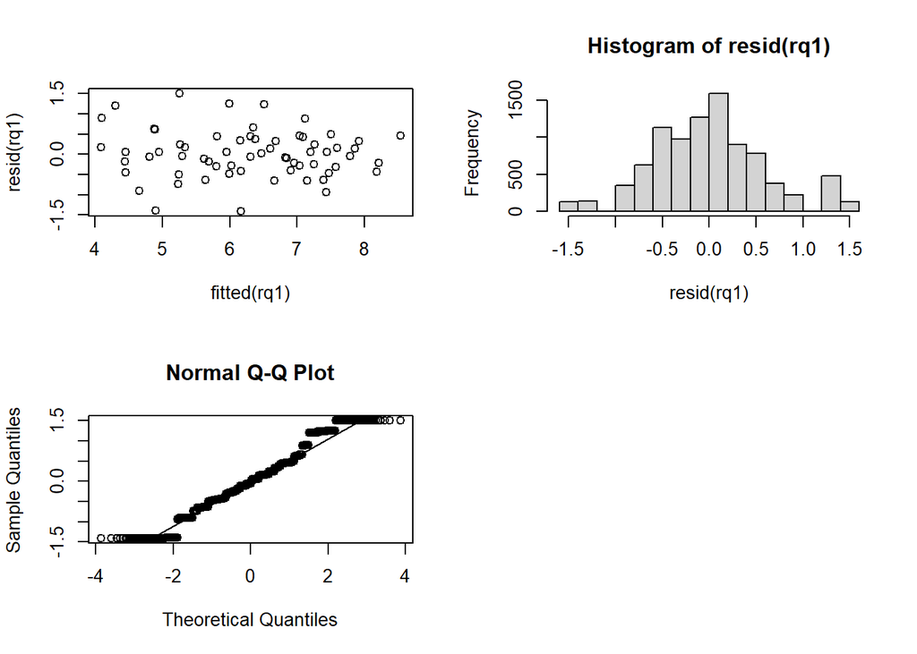

```r
par(mfrow=c(2,2))
plot(fitted(rq1), resid(rq1))
hist(resid(rq1))
qqnorm(resid(rq1));qqline(resid(rq1))
```